# Risk Factor Analysis

## Outcome Variable

**Outcome Variable:** stunted

## Predictor Variables

**Intervention Variable:** single

**Adjustment Set:**

unadjusted

## Stratifying Variables

The analysis was stratified on these variable(s):

- agecat
- studyid
- country

## Data Summary

| agecat | studyid | country | A | n | nA | nAY0 | nAY1 |
| --- | --- | --- | --- | --- | --- | --- | --- |
| Birth | ki0047075b-MAL-ED | BANGLADESH | 0 | 257 | 257 | 210 | 47 |
| Birth | ki0047075b-MAL-ED | BANGLADESH | 1 | 257 | 0 | 0 | 0 |
| Birth | ki0047075b-MAL-ED | BRAZIL | 0 | 191 | 166 | 151 | 15 |
| Birth | ki0047075b-MAL-ED | BRAZIL | 1 | 191 | 25 | 19 | 6 |
| Birth | ki0047075b-MAL-ED | INDIA | 0 | 205 | 205 | 173 | 32 |
| Birth | ki0047075b-MAL-ED | INDIA | 1 | 205 | 0 | 0 | 0 |
| Birth | ki0047075b-MAL-ED | NEPAL | 0 | 173 | 173 | 155 | 18 |
| Birth | ki0047075b-MAL-ED | NEPAL | 1 | 173 | 0 | 0 | 0 |
| Birth | ki0047075b-MAL-ED | PERU | 0 | 287 | 253 | 226 | 27 |
| Birth | ki0047075b-MAL-ED | PERU | 1 | 287 | 34 | 27 | 7 |
| Birth | ki0047075b-MAL-ED | SOUTH AFRICA | 0 | 262 | 146 | 133 | 13 |
| Birth | ki0047075b-MAL-ED | SOUTH AFRICA | 1 | 262 | 116 | 101 | 15 |
| Birth | ki0047075b-MAL-ED | TANZANIA, UNITED REPUBLIC OF | 0 | 123 | 117 | 100 | 17 |
| Birth | ki0047075b-MAL-ED | TANZANIA, UNITED REPUBLIC OF | 1 | 123 | 6 | 5 | 1 |
| Birth | ki1126311-ZVITAMBO | ZIMBABWE | 0 | 13772 | 12902 | 11582 | 1320 |
| Birth | ki1126311-ZVITAMBO | ZIMBABWE | 1 | 13772 | 870 | 763 | 107 |
| Birth | ki1135781-COHORTS | GUATEMALA | 0 | 363 | 334 | 318 | 16 |
| Birth | ki1135781-COHORTS | GUATEMALA | 1 | 363 | 29 | 28 | 1 |
| Birth | ki1135781-COHORTS | INDIA | 0 | 4778 | 4771 | 4206 | 565 |
| Birth | ki1135781-COHORTS | INDIA | 1 | 4778 | 7 | 7 | 0 |
| Birth | ki1135781-COHORTS | PHILIPPINES | 0 | 3010 | 2936 | 2760 | 176 |
| Birth | ki1135781-COHORTS | PHILIPPINES | 1 | 3010 | 74 | 68 | 6 |
| 3 months | ki0047075b-MAL-ED | BANGLADESH | 0 | 250 | 250 | 207 | 43 |
| 3 months | ki0047075b-MAL-ED | BANGLADESH | 1 | 250 | 0 | 0 | 0 |
| 3 months | ki0047075b-MAL-ED | BRAZIL | 0 | 225 | 191 | 181 | 10 |
| 3 months | ki0047075b-MAL-ED | BRAZIL | 1 | 225 | 34 | 30 | 4 |
| 3 months | ki0047075b-MAL-ED | INDIA | 0 | 239 | 239 | 205 | 34 |
| 3 months | ki0047075b-MAL-ED | INDIA | 1 | 239 | 0 | 0 | 0 |
| 3 months | ki0047075b-MAL-ED | NEPAL | 0 | 236 | 236 | 223 | 13 |
| 3 months | ki0047075b-MAL-ED | NEPAL | 1 | 236 | 0 | 0 | 0 |

[output cut: 142 more lines]

The following strata were considered:

- agecat: 12 months, studyid: ki0047075b-MAL-ED, country: BANGLADESH
- agecat: 12 months, studyid: ki0047075b-MAL-ED, country: BRAZIL
- agecat: 12 months, studyid: ki0047075b-MAL-ED, country: INDIA
- agecat: 12 months, studyid: ki0047075b-MAL-ED, country: NEPAL
- agecat: 12 months, studyid: ki0047075b-MAL-ED, country: PERU
- agecat: 12 months, studyid: ki0047075b-MAL-ED, country: SOUTH AFRICA
- agecat: 12 months, studyid: ki0047075b-MAL-ED, country: TANZANIA, UNITED REPUBLIC OF
- agecat: 12 months, studyid: ki1066203-TanzaniaChild2, country: TANZANIA, UNITED REPUBLIC OF
- agecat: 12 months, studyid: ki1112895-Guatemala BSC, country: GUATEMALA
- agecat: 12 months, studyid: ki1126311-ZVITAMBO, country: ZIMBABWE
- agecat: 12 months, studyid: ki1135781-COHORTS, country: GUATEMALA
- agecat: 12 months, studyid: ki1135781-COHORTS, country: INDIA
- agecat: 12 months, studyid: ki1135781-COHORTS, country: PHILIPPINES
- agecat: 18 months, studyid: ki0047075b-MAL-ED, country: BANGLADESH
- agecat: 18 months, studyid: ki0047075b-MAL-ED, country: BRAZIL
- agecat: 18 months, studyid: ki0047075b-MAL-ED, country: INDIA
- agecat: 18 months, studyid: ki0047075b-MAL-ED, country: NEPAL
- agecat: 18 months, studyid: ki0047075b-MAL-ED, country: PERU
- agecat: 18 months, studyid: ki0047075b-MAL-ED, country: SOUTH AFRICA
- agecat: 18 months, studyid: ki0047075b-MAL-ED, country: TANZANIA, UNITED REPUBLIC OF
- agecat: 18 months, studyid: ki1066203-TanzaniaChild2, country: TANZANIA, UNITED REPUBLIC OF
- agecat: 18 months, studyid: ki1126311-ZVITAMBO, country: ZIMBABWE
- agecat: 18 months, studyid: ki1135781-COHORTS, country: GUATEMALA
- agecat: 18 months, studyid: ki1135781-COHORTS, country: PHILIPPINES
- agecat: 24 months, studyid: ki0047075b-MAL-ED, country: BANGLADESH
- agecat: 24 months, studyid: ki0047075b-MAL-ED, country: BRAZIL
- agecat: 24 months, studyid: ki0047075b-MAL-ED, country: INDIA
- agecat: 24 months, studyid: ki0047075b-MAL-ED, country: NEPAL
- agecat: 24 months, studyid: ki0047075b-MAL-ED, country: PERU
- agecat: 24 months, studyid: ki0047075b-MAL-ED, country: SOUTH AFRICA
- agecat: 24 months, studyid: ki0047075b-MAL-ED, country: TANZANIA, UNITED REPUBLIC OF
- agecat: 24 months, studyid: ki1066203-TanzaniaChild2, country: TANZANIA, UNITED REPUBLIC OF
- agecat: 24 months, studyid: ki1126311-ZVITAMBO, country: ZIMBABWE
- agecat: 24 months, studyid: ki1135781-COHORTS, country: GUATEMALA
- agecat: 24 months, studyid: ki1135781-COHORTS, country: INDIA
- agecat: 24 months, studyid: ki1135781-COHORTS, country: PHILIPPINES
- agecat: 3 months, studyid: ki0047075b-MAL-ED, country: BANGLADESH
- agecat: 3 months, studyid: ki0047075b-MAL-ED, country: BRAZIL
- agecat: 3 months, studyid: ki0047075b-MAL-ED, country: INDIA
- agecat: 3 months, studyid: ki0047075b-MAL-ED, country: NEPAL
- agecat: 3 months, studyid: ki0047075b-MAL-ED, country: PERU
- agecat: 3 months, studyid: ki0047075b-MAL-ED, country: SOUTH AFRICA
- agecat: 3 months, studyid: ki0047075b-MAL-ED, country: TANZANIA, UNITED REPUBLIC OF
- agecat: 3 months, studyid: ki1066203-TanzaniaChild2, country: TANZANIA, UNITED REPUBLIC OF
- agecat: 3 months, studyid: ki1112895-Guatemala BSC, country: GUATEMALA
- agecat: 3 months, studyid: ki1126311-ZVITAMBO, country: ZIMBABWE
- agecat: 3 months, studyid: ki1135781-COHORTS, country: GUATEMALA
- agecat: 3 months, studyid: ki1135781-COHORTS, country: INDIA
- agecat: 3 months, studyid: ki1135781-COHORTS, country: PHILIPPINES
- agecat: 6 months, studyid: ki0047075b-MAL-ED, country: BANGLADESH
- agecat: 6 months, studyid: ki0047075b-MAL-ED, country: BRAZIL
- agecat: 6 months, studyid: ki0047075b-MAL-ED, country: INDIA
- agecat: 6 months, studyid: ki0047075b-MAL-ED, country: NEPAL
- agecat: 6 months, studyid: ki0047075b-MAL-ED, country: PERU
- agecat: 6 months, studyid: ki0047075b-MAL-ED, country: SOUTH AFRICA
- agecat: 6 months, studyid: ki0047075b-MAL-ED, country: TANZANIA, UNITED REPUBLIC OF
- agecat: 6 months, studyid: ki1066203-TanzaniaChild2, country: TANZANIA, UNITED REPUBLIC OF
- agecat: 6 months, studyid: ki1112895-Guatemala BSC, country: GUATEMALA
- agecat: 6 months, studyid: ki1126311-ZVITAMBO, country: ZIMBABWE
- agecat: 6 months, studyid: ki1135781-COHORTS, country: GUATEMALA
- agecat: 6 months, studyid: ki1135781-COHORTS, country: INDIA
- agecat: 6 months, studyid: ki1135781-COHORTS, country: PHILIPPINES
- agecat: 9 months, studyid: ki0047075b-MAL-ED, country: BANGLADESH
- agecat: 9 months, studyid: ki0047075b-MAL-ED, country: BRAZIL
- agecat: 9 months, studyid: ki0047075b-MAL-ED, country: INDIA
- agecat: 9 months, studyid: ki0047075b-MAL-ED, country: NEPAL
- agecat: 9 months, studyid: ki0047075b-MAL-ED, country: PERU
- agecat: 9 months, studyid: ki0047075b-MAL-ED, country: SOUTH AFRICA
- agecat: 9 months, studyid: ki0047075b-MAL-ED, country: TANZANIA, UNITED REPUBLIC OF
- agecat: 9 months, studyid: ki1066203-TanzaniaChild2, country: TANZANIA, UNITED REPUBLIC OF
- agecat: 9 months, studyid: ki1112895-Guatemala BSC, country: GUATEMALA
- agecat: 9 months, studyid: ki1126311-ZVITAMBO, country: ZIMBABWE
- agecat: 9 months, studyid: ki1135781-COHORTS, country: GUATEMALA
- agecat: 9 months, studyid: ki1135781-COHORTS, country: INDIA
- agecat: 9 months, studyid: ki1135781-COHORTS, country: PHILIPPINES
- agecat: Birth, studyid: ki0047075b-MAL-ED, country: BANGLADESH
- agecat: Birth, studyid: ki0047075b-MAL-ED, country: BRAZIL
- agecat: Birth, studyid: ki0047075b-MAL-ED, country: INDIA
- agecat: Birth, studyid: ki0047075b-MAL-ED, country: NEPAL
- agecat: Birth, studyid: ki0047075b-MAL-ED, country: PERU
- agecat: Birth, studyid: ki0047075b-MAL-ED, country: SOUTH AFRICA
- agecat: Birth, studyid: ki0047075b-MAL-ED, country: TANZANIA, UNITED REPUBLIC OF
- agecat: Birth, studyid: ki1126311-ZVITAMBO, country: ZIMBABWE
- agecat: Birth, studyid: ki1135781-COHORTS, country: GUATEMALA
- agecat: Birth, studyid: ki1135781-COHORTS, country: INDIA
- agecat: Birth, studyid: ki1135781-COHORTS, country: PHILIPPINES

### Dropped Strata

Some strata were dropped due to rare outcomes:

- agecat: Birth, studyid: ki0047075b-MAL-ED, country: BANGLADESH
- agecat: Birth, studyid: ki0047075b-MAL-ED, country: INDIA
- agecat: Birth, studyid: ki0047075b-MAL-ED, country: NEPAL
- agecat: Birth, studyid: ki0047075b-MAL-ED, country: TANZANIA, UNITED REPUBLIC OF
- agecat: Birth, studyid: ki1135781-COHORTS, country: GUATEMALA
- agecat: Birth, studyid: ki1135781-COHORTS, country: INDIA
- agecat: 3 months, studyid: ki0047075b-MAL-ED, country: BANGLADESH
- agecat: 3 months, studyid: ki0047075b-MAL-ED, country: BRAZIL
- agecat: 3 months, studyid: ki0047075b-MAL-ED, country: INDIA
- agecat: 3 months, studyid: ki0047075b-MAL-ED, country: NEPAL
- agecat: 3 months, studyid: ki0047075b-MAL-ED, country: TANZANIA, UNITED REPUBLIC OF
- agecat: 3 months, studyid: ki1112895-Guatemala BSC, country: GUATEMALA
- agecat: 3 months, studyid: ki1135781-COHORTS, country: INDIA
- agecat: 6 months, studyid: ki0047075b-MAL-ED, country: BANGLADESH
- agecat: 6 months, studyid: ki0047075b-MAL-ED, country: BRAZIL
- agecat: 6 months, studyid: ki0047075b-MAL-ED, country: INDIA
- agecat: 6 months, studyid: ki0047075b-MAL-ED, country: NEPAL
- agecat: 6 months, studyid: ki0047075b-MAL-ED, country: TANZANIA, UNITED REPUBLIC OF
- agecat: 6 months, studyid: ki1135781-COHORTS, country: INDIA
- agecat: 9 months, studyid: ki0047075b-MAL-ED, country: BANGLADESH
- agecat: 9 months, studyid: ki0047075b-MAL-ED, country: BRAZIL
- agecat: 9 months, studyid: ki0047075b-MAL-ED, country: INDIA
- agecat: 9 months, studyid: ki0047075b-MAL-ED, country: NEPAL
- agecat: 9 months, studyid: ki0047075b-MAL-ED, country: TANZANIA, UNITED REPUBLIC OF
- agecat: 9 months, studyid: ki1135781-COHORTS, country: INDIA
- agecat: 12 months, studyid: ki0047075b-MAL-ED, country: BANGLADESH
- agecat: 12 months, studyid: ki0047075b-MAL-ED, country: BRAZIL
- agecat: 12 months, studyid: ki0047075b-MAL-ED, country: INDIA
- agecat: 12 months, studyid: ki0047075b-MAL-ED, country: NEPAL
- agecat: 12 months, studyid: ki0047075b-MAL-ED, country: TANZANIA, UNITED REPUBLIC OF
- agecat: 12 months, studyid: ki1135781-COHORTS, country: INDIA
- agecat: 18 months, studyid: ki0047075b-MAL-ED, country: BANGLADESH
- agecat: 18 months, studyid: ki0047075b-MAL-ED, country: BRAZIL
- agecat: 18 months, studyid: ki0047075b-MAL-ED, country: INDIA
- agecat: 18 months, studyid: ki0047075b-MAL-ED, country: NEPAL
- agecat: 18 months, studyid: ki0047075b-MAL-ED, country: TANZANIA, UNITED REPUBLIC OF
- agecat: 24 months, studyid: ki0047075b-MAL-ED, country: BANGLADESH
- agecat: 24 months, studyid: ki0047075b-MAL-ED, country: BRAZIL
- agecat: 24 months, studyid: ki0047075b-MAL-ED, country: INDIA
- agecat: 24 months, studyid: ki0047075b-MAL-ED, country: NEPAL
- agecat: 24 months, studyid: ki0047075b-MAL-ED, country: TANZANIA, UNITED REPUBLIC OF
- agecat: 24 months, studyid: ki1066203-TanzaniaChild2, country: TANZANIA, UNITED REPUBLIC OF
- agecat: 24 months, studyid: ki1135781-COHORTS, country: INDIA

## Methods Detail

We’re interested in the causal parameters $E[Y_a]$ for all values of $a \in \mathcal{A}$. These parameters represent the mean outcome if, possibly contrary to fact, we intervened to set all units to have $A=a$. Under the randomization and positivity assumptions, these are identified by the statistical parameters $\psi_a=E_W[E_{Y|A,W}(Y|A=a,W)]$. In addition, we’re interested in the mean of $Y$, $E[Y]$ under no intervention (the observed mean). We will estimate these parameters by using SuperLearner to fit the relevant likelihood factors – $E_{Y|A,W}(Y|A=a,W)$ and $p(A=a|W)$, and then updating our likelihood fit using a joint TMLE.

For unadjusted analyses ($W=\{\}$), initial likelihoods were estimated using Lrnr_glm to estimate the simple $E(Y|A)$ and Lrnr_mean to estimate $p(A)$. For adjusted analyses, a small library containing Lrnr_glmnet, Lrnr_xgboost, and Lrnr_mean was used.

Having estimated these parameters, we will then use the delta method to estimate relative risks and attributable risks relative to a prespecified baseline level of $A$.

# Results Detail

## Results Plots

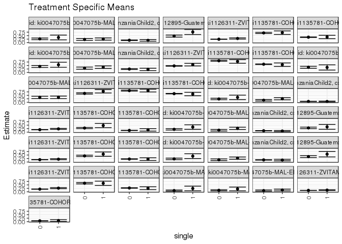

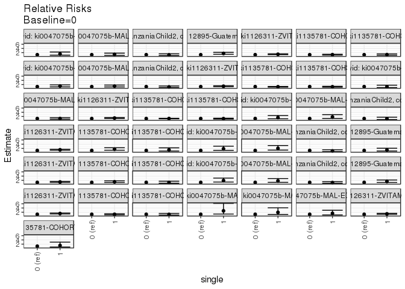

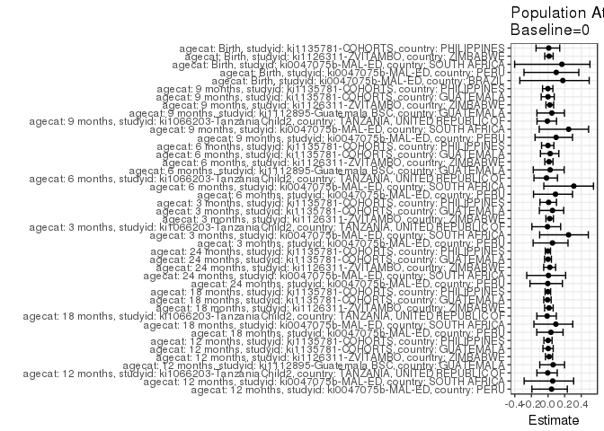

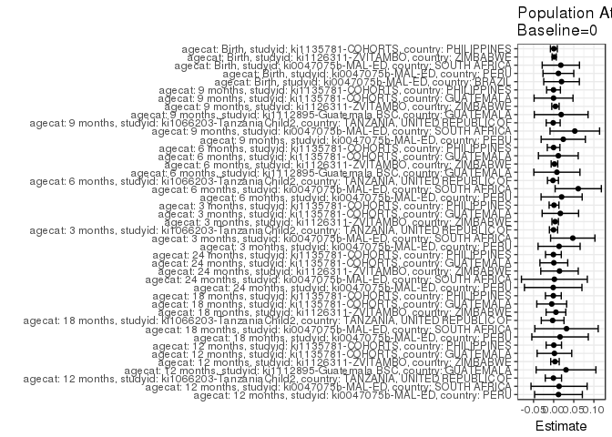

## Results Table

### Parameter: TSM

| agecat | studyid | country | intervention_level | baseline_level | estimate | ci_lower | ci_upper |
| --- | --- | --- | --- | --- | --- | --- | --- |
| Birth | ki0047075b-MAL-ED | BRAZIL | 0 | NA | 0.0903614 | 0.0466334 | 0.1340895 |
| Birth | ki0047075b-MAL-ED | BRAZIL | 1 | NA | 0.2400000 | 0.0721465 | 0.4078535 |
| Birth | ki0047075b-MAL-ED | PERU | 0 | NA | 0.1067194 | 0.0686074 | 0.1448313 |
| Birth | ki0047075b-MAL-ED | PERU | 1 | NA | 0.2058824 | 0.0697321 | 0.3420326 |
| Birth | ki0047075b-MAL-ED | SOUTH AFRICA | 0 | NA | 0.0890411 | 0.0427554 | 0.1353268 |
| Birth | ki0047075b-MAL-ED | SOUTH AFRICA | 1 | NA | 0.1293103 | 0.0681320 | 0.1904887 |
| Birth | ki1126311-ZVITAMBO | ZIMBABWE | 0 | NA | 0.1023097 | 0.0970803 | 0.1075392 |
| Birth | ki1126311-ZVITAMBO | ZIMBABWE | 1 | NA | 0.1229885 | 0.1011643 | 0.1448127 |
| Birth | ki1135781-COHORTS | PHILIPPINES | 0 | NA | 0.0599455 | 0.0513574 | 0.0685336 |
| Birth | ki1135781-COHORTS | PHILIPPINES | 1 | NA | 0.0810811 | 0.0188793 | 0.1432829 |
| 3 months | ki0047075b-MAL-ED | PERU | 0 | NA | 0.2373541 | 0.1852480 | 0.2894602 |
| 3 months | ki0047075b-MAL-ED | PERU | 1 | NA | 0.3529412 | 0.1920326 | 0.5138497 |
| 3 months | ki0047075b-MAL-ED | SOUTH AFRICA | 0 | NA | 0.1446541 | 0.0898819 | 0.1994263 |
| 3 months | ki0047075b-MAL-ED | SOUTH AFRICA | 1 | NA | 0.2540984 | 0.1767085 | 0.3314882 |
| 3 months | ki1066203-TanzaniaChild2 | TANZANIA, UNITED REPUBLIC OF | 0 | NA | 0.0597377 | 0.0494986 | 0.0699769 |
| 3 months | ki1066203-TanzaniaChild2 | TANZANIA, UNITED REPUBLIC OF | 1 | NA | 0.0558140 | 0.0251220 | 0.0865059 |
| 3 months | ki1126311-ZVITAMBO | ZIMBABWE | 0 | NA | 0.1742777 | 0.1662524 | 0.1823031 |
| 3 months | ki1126311-ZVITAMBO | ZIMBABWE | 1 | NA | 0.2334495 | 0.1988410 | 0.2680580 |
| 3 months | ki1135781-COHORTS | GUATEMALA | 0 | NA | 0.2944162 | 0.2493599 | 0.3394726 |
| 3 months | ki1135781-COHORTS | GUATEMALA | 1 | NA | 0.4750000 | 0.3200665 | 0.6299335 |
| 3 months | ki1135781-COHORTS | PHILIPPINES | 0 | NA | 0.1220217 | 0.1098305 | 0.1342128 |
| 3 months | ki1135781-COHORTS | PHILIPPINES | 1 | NA | 0.1594203 | 0.0730307 | 0.2458099 |
| 6 months | ki0047075b-MAL-ED | PERU | 0 | NA | 0.2000000 | 0.1493010 | 0.2506990 |
| 6 months | ki0047075b-MAL-ED | PERU | 1 | NA | 0.3636364 | 0.1992089 | 0.5280638 |
| 6 months | ki0047075b-MAL-ED | SOUTH AFRICA | 0 | NA | 0.1357143 | 0.0788706 | 0.1925580 |
| 6 months | ki0047075b-MAL-ED | SOUTH AFRICA | 1 | NA | 0.2719298 | 0.1900895 | 0.3537701 |
| 6 months | ki1066203-TanzaniaChild2 | TANZANIA, UNITED REPUBLIC OF | 0 | NA | 0.0986376 | 0.0849915 | 0.1122837 |
| 6 months | ki1066203-TanzaniaChild2 | TANZANIA, UNITED REPUBLIC OF | 1 | NA | 0.0786517 | 0.0390957 | 0.1182076 |
| 6 months | ki1112895-Guatemala BSC | GUATEMALA | 0 | NA | 0.3024194 | 0.2451517 | 0.3596870 |
| 6 months | ki1112895-Guatemala BSC | GUATEMALA | 1 | NA | 0.3793103 | 0.2023936 | 0.5562271 |

[output cut: 56 more lines]

### Parameter: E(Y)

| agecat | studyid | country | intervention_level | baseline_level | estimate | ci_lower | ci_upper |
| --- | --- | --- | --- | --- | --- | --- | --- |
| Birth | ki0047075b-MAL-ED | BRAZIL | NA | NA | 0.1099476 | 0.1027713 | 0.1171240 |
| Birth | ki0047075b-MAL-ED | PERU | NA | NA | 0.1184669 | 0.1147530 | 0.1221808 |
| Birth | ki0047075b-MAL-ED | SOUTH AFRICA | NA | NA | 0.1068702 | 0.1044436 | 0.1092969 |
| Birth | ki1126311-ZVITAMBO | ZIMBABWE | NA | NA | 0.1036160 | 0.1035320 | 0.1037001 |
| Birth | ki1135781-COHORTS | PHILIPPINES | NA | NA | 0.0604651 | 0.0603482 | 0.0605821 |
| 3 months | ki0047075b-MAL-ED | PERU | NA | NA | 0.2508591 | 0.2465857 | 0.2551325 |
| 3 months | ki0047075b-MAL-ED | SOUTH AFRICA | NA | NA | 0.1921708 | 0.1858170 | 0.1985246 |
| 3 months | ki1066203-TanzaniaChild2 | TANZANIA, UNITED REPUBLIC OF | NA | NA | 0.0593668 | 0.0593196 | 0.0594140 |
| 3 months | ki1126311-ZVITAMBO | ZIMBABWE | NA | NA | 0.1779865 | 0.1776927 | 0.1782802 |
| 3 months | ki1135781-COHORTS | GUATEMALA | NA | NA | 0.3110599 | 0.3061398 | 0.3159800 |
| 3 months | ki1135781-COHORTS | PHILIPPINES | NA | NA | 0.1229306 | 0.1227187 | 0.1231425 |
| 6 months | ki0047075b-MAL-ED | PERU | NA | NA | 0.2197802 | 0.2134409 | 0.2261196 |
| 6 months | ki0047075b-MAL-ED | SOUTH AFRICA | NA | NA | 0.1968504 | 0.1885021 | 0.2051987 |
| 6 months | ki1066203-TanzaniaChild2 | TANZANIA, UNITED REPUBLIC OF | NA | NA | 0.0968703 | 0.0966224 | 0.0971183 |
| 6 months | ki1112895-Guatemala BSC | GUATEMALA | NA | NA | 0.3104693 | 0.3076921 | 0.3132466 |
| 6 months | ki1126311-ZVITAMBO | ZIMBABWE | NA | NA | 0.1662432 | 0.1660715 | 0.1664149 |
| 6 months | ki1135781-COHORTS | GUATEMALA | NA | NA | 0.4485981 | 0.4451292 | 0.4520670 |
| 6 months | ki1135781-COHORTS | PHILIPPINES | NA | NA | 0.2118834 | 0.2118467 | 0.2119201 |
| 9 months | ki0047075b-MAL-ED | PERU | NA | NA | 0.2460938 | 0.2382003 | 0.2539872 |
| 9 months | ki0047075b-MAL-ED | SOUTH AFRICA | NA | NA | 0.2120000 | 0.2047507 | 0.2192493 |
| 9 months | ki1066203-TanzaniaChild2 | TANZANIA, UNITED REPUBLIC OF | NA | NA | 0.1480023 | 0.1478223 | 0.1481822 |
| 9 months | ki1112895-Guatemala BSC | GUATEMALA | NA | NA | 0.4051724 | 0.3982338 | 0.4121111 |
| 9 months | ki1126311-ZVITAMBO | ZIMBABWE | NA | NA | 0.1975147 | 0.1971276 | 0.1979018 |
| 9 months | ki1135781-COHORTS | GUATEMALA | NA | NA | 0.6182670 | 0.6181802 | 0.6183538 |
| 9 months | ki1135781-COHORTS | PHILIPPINES | NA | NA | 0.2754759 | 0.2753860 | 0.2755659 |
| 12 months | ki0047075b-MAL-ED | PERU | NA | NA | 0.2804878 | 0.2764662 | 0.2845094 |
| 12 months | ki0047075b-MAL-ED | SOUTH AFRICA | NA | NA | 0.2380952 | 0.2362635 | 0.2399270 |
| 12 months | ki1066203-TanzaniaChild2 | TANZANIA, UNITED REPUBLIC OF | NA | NA | 0.1655076 | 0.1654022 | 0.1656131 |
| 12 months | ki1112895-Guatemala BSC | GUATEMALA | NA | NA | 0.5000000 | 0.4875363 | 0.5124637 |
| 12 months | ki1126311-ZVITAMBO | ZIMBABWE | NA | NA | 0.2447948 | 0.2444922 | 0.2450973 |
| 12 months | ki1135781-COHORTS | GUATEMALA | NA | NA | 0.6973415 | 0.6968398 | 0.6978432 |
| 12 months | ki1135781-COHORTS | PHILIPPINES | NA | NA | 0.3886497 | 0.3885606 | 0.3887389 |
| 18 months | ki0047075b-MAL-ED | PERU | NA | NA | 0.4459459 | 0.4405400 | 0.4513519 |
| 18 months | ki0047075b-MAL-ED | SOUTH AFRICA | NA | NA | 0.3402490 | 0.3357593 | 0.3447386 |
| 18 months | ki1066203-TanzaniaChild2 | TANZANIA, UNITED REPUBLIC OF | NA | NA | 0.2415558 | 0.2410496 | 0.2420620 |
| 18 months | ki1126311-ZVITAMBO | ZIMBABWE | NA | NA | 0.4759672 | 0.4749262 | 0.4770082 |
| 18 months | ki1135781-COHORTS | GUATEMALA | NA | NA | 0.8369830 | 0.8355152 | 0.8384508 |
| 18 months | ki1135781-COHORTS | PHILIPPINES | NA | NA | 0.5895977 | 0.5893947 | 0.5898007 |
| 24 months | ki0047075b-MAL-ED | PERU | NA | NA | 0.3681592 | 0.3677330 | 0.3685854 |
| 24 months | ki0047075b-MAL-ED | SOUTH AFRICA | NA | NA | 0.3529412 | 0.3526882 | 0.3531942 |
| 24 months | ki1126311-ZVITAMBO | ZIMBABWE | NA | NA | 0.6513158 | 0.6471833 | 0.6554482 |
| 24 months | ki1135781-COHORTS | GUATEMALA | NA | NA | 0.8395062 | 0.8393955 | 0.8396168 |
| 24 months | ki1135781-COHORTS | PHILIPPINES | NA | NA | 0.6196192 | 0.6194526 | 0.6197858 |

### Parameter: RR

| agecat | studyid | country | intervention_level | baseline_level | estimate | ci_lower | ci_upper |
| --- | --- | --- | --- | --- | --- | --- | --- |
| Birth | ki0047075b-MAL-ED | BRAZIL | 0 | 0 | 1.0000000 | 1.0000000 | 1.000000 |
| Birth | ki0047075b-MAL-ED | BRAZIL | 1 | 0 | 2.6560000 | 1.1346616 | 6.217128 |
| Birth | ki0047075b-MAL-ED | PERU | 0 | 0 | 1.0000000 | 1.0000000 | 1.000000 |
| Birth | ki0047075b-MAL-ED | PERU | 1 | 0 | 1.9291939 | 0.9098576 | 4.090518 |
| Birth | ki0047075b-MAL-ED | SOUTH AFRICA | 0 | 0 | 1.0000000 | 1.0000000 | 1.000000 |
| Birth | ki0047075b-MAL-ED | SOUTH AFRICA | 1 | 0 | 1.4522546 | 0.7190881 | 2.932942 |
| Birth | ki1126311-ZVITAMBO | ZIMBABWE | 0 | 0 | 1.0000000 | 1.0000000 | 1.000000 |
| Birth | ki1126311-ZVITAMBO | ZIMBABWE | 1 | 0 | 1.2021195 | 0.9994220 | 1.445927 |
| Birth | ki1135781-COHORTS | PHILIPPINES | 0 | 0 | 1.0000000 | 1.0000000 | 1.000000 |
| Birth | ki1135781-COHORTS | PHILIPPINES | 1 | 0 | 1.3525799 | 0.6197717 | 2.951849 |
| 3 months | ki0047075b-MAL-ED | PERU | 0 | 0 | 1.0000000 | 1.0000000 | 1.000000 |
| 3 months | ki0047075b-MAL-ED | PERU | 1 | 0 | 1.4869817 | 0.8964970 | 2.466394 |
| 3 months | ki0047075b-MAL-ED | SOUTH AFRICA | 0 | 0 | 1.0000000 | 1.0000000 | 1.000000 |
| 3 months | ki0047075b-MAL-ED | SOUTH AFRICA | 1 | 0 | 1.7565930 | 1.0805209 | 2.855677 |
| 3 months | ki1066203-TanzaniaChild2 | TANZANIA, UNITED REPUBLIC OF | 0 | 0 | 1.0000000 | 1.0000000 | 1.000000 |
| 3 months | ki1066203-TanzaniaChild2 | TANZANIA, UNITED REPUBLIC OF | 1 | 0 | 0.9343165 | 0.5252236 | 1.662049 |
| 3 months | ki1126311-ZVITAMBO | ZIMBABWE | 0 | 0 | 1.0000000 | 1.0000000 | 1.000000 |
| 3 months | ki1126311-ZVITAMBO | ZIMBABWE | 1 | 0 | 1.3395256 | 1.1469198 | 1.564476 |
| 3 months | ki1135781-COHORTS | GUATEMALA | 0 | 0 | 1.0000000 | 1.0000000 | 1.000000 |
| 3 months | ki1135781-COHORTS | GUATEMALA | 1 | 0 | 1.6133621 | 1.1252751 | 2.313156 |
| 3 months | ki1135781-COHORTS | PHILIPPINES | 0 | 0 | 1.0000000 | 1.0000000 | 1.000000 |
| 3 months | ki1135781-COHORTS | PHILIPPINES | 1 | 0 | 1.3064917 | 0.7530031 | 2.266818 |
| 6 months | ki0047075b-MAL-ED | PERU | 0 | 0 | 1.0000000 | 1.0000000 | 1.000000 |
| 6 months | ki0047075b-MAL-ED | PERU | 1 | 0 | 1.8181818 | 1.0826943 | 3.053295 |
| 6 months | ki0047075b-MAL-ED | SOUTH AFRICA | 0 | 0 | 1.0000000 | 1.0000000 | 1.000000 |
| 6 months | ki0047075b-MAL-ED | SOUTH AFRICA | 1 | 0 | 2.0036934 | 1.1962950 | 3.356018 |
| 6 months | ki1066203-TanzaniaChild2 | TANZANIA, UNITED REPUBLIC OF | 0 | 0 | 1.0000000 | 1.0000000 | 1.000000 |
| 6 months | ki1066203-TanzaniaChild2 | TANZANIA, UNITED REPUBLIC OF | 1 | 0 | 0.7973803 | 0.4732978 | 1.343373 |
| 6 months | ki1112895-Guatemala BSC | GUATEMALA | 0 | 0 | 1.0000000 | 1.0000000 | 1.000000 |
| 6 months | ki1112895-Guatemala BSC | GUATEMALA | 1 | 0 | 1.2542529 | 0.7581664 | 2.074941 |

[output cut: 56 more lines]

### Parameter: PAR

| agecat | studyid | country | intervention_level | baseline_level | estimate | ci_lower | ci_upper |
| --- | --- | --- | --- | --- | --- | --- | --- |
| Birth | ki0047075b-MAL-ED | BRAZIL | 0 | NA | 0.0195862 | -0.0247268 | 0.0638992 |
| Birth | ki0047075b-MAL-ED | PERU | 0 | NA | 0.0117475 | -0.0265450 | 0.0500400 |
| Birth | ki0047075b-MAL-ED | SOUTH AFRICA | 0 | NA | 0.0178291 | -0.0285201 | 0.0641784 |
| Birth | ki1126311-ZVITAMBO | ZIMBABWE | 0 | NA | 0.0013063 | -0.0039238 | 0.0065365 |
| Birth | ki1135781-COHORTS | PHILIPPINES | 0 | NA | 0.0005196 | -0.0080693 | 0.0091085 |
| 3 months | ki0047075b-MAL-ED | PERU | 0 | NA | 0.0135050 | -0.0387761 | 0.0657861 |
| 3 months | ki0047075b-MAL-ED | SOUTH AFRICA | 0 | NA | 0.0475167 | -0.0076227 | 0.1026562 |
| 3 months | ki1066203-TanzaniaChild2 | TANZANIA, UNITED REPUBLIC OF | 0 | NA | -0.0003710 | -0.0106103 | 0.0098683 |
| 3 months | ki1126311-ZVITAMBO | ZIMBABWE | 0 | NA | 0.0037087 | -0.0043220 | 0.0117395 |
| 3 months | ki1135781-COHORTS | GUATEMALA | 0 | NA | 0.0166437 | -0.0286805 | 0.0619679 |
| 3 months | ki1135781-COHORTS | PHILIPPINES | 0 | NA | 0.0009089 | -0.0112841 | 0.0131020 |
| 6 months | ki0047075b-MAL-ED | PERU | 0 | NA | 0.0197802 | -0.0313136 | 0.0708740 |
| 6 months | ki0047075b-MAL-ED | SOUTH AFRICA | 0 | NA | 0.0611361 | 0.0036827 | 0.1185895 |
| 6 months | ki1066203-TanzaniaChild2 | TANZANIA, UNITED REPUBLIC OF | 0 | NA | -0.0017673 | -0.0154156 | 0.0118811 |
| 6 months | ki1112895-Guatemala BSC | GUATEMALA | 0 | NA | 0.0080500 | -0.0492850 | 0.0653849 |
| 6 months | ki1126311-ZVITAMBO | ZIMBABWE | 0 | NA | 0.0019988 | -0.0062388 | 0.0102365 |
| 6 months | ki1135781-COHORTS | GUATEMALA | 0 | NA | 0.0115801 | -0.0378906 | 0.0610509 |
| 6 months | ki1135781-COHORTS | PHILIPPINES | 0 | NA | -0.0001565 | -0.0158470 | 0.0155341 |
| 9 months | ki0047075b-MAL-ED | PERU | 0 | NA | 0.0238715 | -0.0311266 | 0.0788697 |
| 9 months | ki0047075b-MAL-ED | SOUTH AFRICA | 0 | NA | 0.0525797 | -0.0090466 | 0.1142060 |
| 9 months | ki1066203-TanzaniaChild2 | TANZANIA, UNITED REPUBLIC OF | 0 | NA | -0.0011963 | -0.0185409 | 0.0161483 |
| 9 months | ki1112895-Guatemala BSC | GUATEMALA | 0 | NA | 0.0186990 | -0.0481401 | 0.0855380 |
| 9 months | ki1126311-ZVITAMBO | ZIMBABWE | 0 | NA | 0.0044295 | -0.0047138 | 0.0135729 |
| 9 months | ki1135781-COHORTS | GUATEMALA | 0 | NA | -0.0002897 | -0.0486787 | 0.0480993 |
| 9 months | ki1135781-COHORTS | PHILIPPINES | 0 | NA | -0.0003861 | -0.0175364 | 0.0167641 |
| 12 months | ki0047075b-MAL-ED | PERU | 0 | NA | 0.0119693 | -0.0473907 | 0.0713292 |
| 12 months | ki0047075b-MAL-ED | SOUTH AFRICA | 0 | NA | 0.0134576 | -0.0563360 | 0.0832511 |
| 12 months | ki1066203-TanzaniaChild2 | TANZANIA, UNITED REPUBLIC OF | 0 | NA | -0.0006486 | -0.0208431 | 0.0195460 |
| 12 months | ki1112895-Guatemala BSC | GUATEMALA | 0 | NA | 0.0307263 | -0.0436183 | 0.1050708 |
| 12 months | ki1126311-ZVITAMBO | ZIMBABWE | 0 | NA | 0.0032297 | -0.0073340 | 0.0137935 |
| 12 months | ki1135781-COHORTS | GUATEMALA | 0 | NA | 0.0018870 | -0.0411614 | 0.0449353 |
| 12 months | ki1135781-COHORTS | PHILIPPINES | 0 | NA | 0.0003625 | -0.0187724 | 0.0194974 |
| 18 months | ki0047075b-MAL-ED | PERU | 0 | NA | 0.0158941 | -0.0543191 | 0.0861074 |
| 18 months | ki0047075b-MAL-ED | SOUTH AFRICA | 0 | NA | 0.0319783 | -0.0467926 | 0.1107492 |
| 18 months | ki1066203-TanzaniaChild2 | TANZANIA, UNITED REPUBLIC OF | 0 | NA | -0.0025387 | -0.0307941 | 0.0257167 |
| 18 months | ki1126311-ZVITAMBO | ZIMBABWE | 0 | NA | 0.0056732 | -0.0188200 | 0.0301665 |
| 18 months | ki1135781-COHORTS | GUATEMALA | 0 | NA | -0.0048401 | -0.0419461 | 0.0322660 |
| 18 months | ki1135781-COHORTS | PHILIPPINES | 0 | NA | -0.0008189 | -0.0204980 | 0.0188601 |
| 24 months | ki0047075b-MAL-ED | PERU | 0 | NA | -0.0011590 | -0.0726395 | 0.0703216 |
| 24 months | ki0047075b-MAL-ED | SOUTH AFRICA | 0 | NA | 0.0017961 | -0.0801156 | 0.0837078 |
| 24 months | ki1126311-ZVITAMBO | ZIMBABWE | 0 | NA | 0.0145119 | -0.0321042 | 0.0611281 |
| 24 months | ki1135781-COHORTS | GUATEMALA | 0 | NA | 0.0004257 | -0.0341411 | 0.0349925 |
| 24 months | ki1135781-COHORTS | PHILIPPINES | 0 | NA | -0.0006608 | -0.0202583 | 0.0189366 |

### Parameter: PAF

| agecat | studyid | country | intervention_level | baseline_level | estimate | ci_lower | ci_upper |
| --- | --- | --- | --- | --- | --- | --- | --- |
| Birth | ki0047075b-MAL-ED | BRAZIL | 0 | NA | 0.1781411 | -0.3392623 | 0.4956537 |
| Birth | ki0047075b-MAL-ED | PERU | 0 | NA | 0.0991630 | -0.2892565 | 0.3705618 |
| Birth | ki0047075b-MAL-ED | SOUTH AFRICA | 0 | NA | 0.1668297 | -0.4018633 | 0.5048214 |
| Birth | ki1126311-ZVITAMBO | ZIMBABWE | 0 | NA | 0.0126072 | -0.0391812 | 0.0618148 |
| Birth | ki1135781-COHORTS | PHILIPPINES | 0 | NA | 0.0085936 | -0.1441333 | 0.1409334 |
| 3 months | ki0047075b-MAL-ED | PERU | 0 | NA | 0.0538351 | -0.1792170 | 0.2408284 |
| 3 months | ki0047075b-MAL-ED | SOUTH AFRICA | 0 | NA | 0.2472630 | -0.1008073 | 0.4852750 |
| 3 months | ki1066203-TanzaniaChild2 | TANZANIA, UNITED REPUBLIC OF | 0 | NA | -0.0062490 | -0.1943872 | 0.1522540 |
| 3 months | ki1126311-ZVITAMBO | ZIMBABWE | 0 | NA | 0.0208372 | -0.0253372 | 0.0649322 |
| 3 months | ki1135781-COHORTS | GUATEMALA | 0 | NA | 0.0535063 | -0.1039123 | 0.1884769 |
| 3 months | ki1135781-COHORTS | PHILIPPINES | 0 | NA | 0.0073940 | -0.0969167 | 0.1017853 |
| 6 months | ki0047075b-MAL-ED | PERU | 0 | NA | 0.0900000 | -0.1744736 | 0.2949181 |
| 6 months | ki0047075b-MAL-ED | SOUTH AFRICA | 0 | NA | 0.3105714 | -0.0503227 | 0.5474612 |
| 6 months | ki1066203-TanzaniaChild2 | TANZANIA, UNITED REPUBLIC OF | 0 | NA | -0.0182436 | -0.1693508 | 0.1133372 |
| 6 months | ki1112895-Guatemala BSC | GUATEMALA | 0 | NA | 0.0259284 | -0.1773968 | 0.1941412 |
| 6 months | ki1126311-ZVITAMBO | ZIMBABWE | 0 | NA | 0.0120235 | -0.0387917 | 0.0603529 |
| 6 months | ki1135781-COHORTS | GUATEMALA | 0 | NA | 0.0258141 | -0.0909332 | 0.1300675 |
| 6 months | ki1135781-COHORTS | PHILIPPINES | 0 | NA | -0.0007385 | -0.0775998 | 0.0706407 |
| 9 months | ki0047075b-MAL-ED | PERU | 0 | NA | 0.0970018 | -0.1560233 | 0.2946459 |
| 9 months | ki0047075b-MAL-ED | SOUTH AFRICA | 0 | NA | 0.2480175 | -0.1055674 | 0.4885181 |
| 9 months | ki1066203-TanzaniaChild2 | TANZANIA, UNITED REPUBLIC OF | 0 | NA | -0.0080828 | -0.1323581 | 0.1025535 |
| 9 months | ki1112895-Guatemala BSC | GUATEMALA | 0 | NA | 0.0461507 | -0.1338426 | 0.1975707 |
| 9 months | ki1126311-ZVITAMBO | ZIMBABWE | 0 | NA | 0.0224264 | -0.0249771 | 0.0676375 |
| 9 months | ki1135781-COHORTS | GUATEMALA | 0 | NA | -0.0004686 | -0.0818769 | 0.0748139 |
| 9 months | ki1135781-COHORTS | PHILIPPINES | 0 | NA | -0.0014017 | -0.0656347 | 0.0589595 |
| 12 months | ki0047075b-MAL-ED | PERU | 0 | NA | 0.0426731 | -0.1941228 | 0.2325121 |
| 12 months | ki0047075b-MAL-ED | SOUTH AFRICA | 0 | NA | 0.0565217 | -0.2872396 | 0.3084806 |
| 12 months | ki1066203-TanzaniaChild2 | TANZANIA, UNITED REPUBLIC OF | 0 | NA | -0.0039186 | -0.1336590 | 0.1109739 |
| 12 months | ki1112895-Guatemala BSC | GUATEMALA | 0 | NA | 0.0614525 | -0.0993701 | 0.1987490 |
| 12 months | ki1126311-ZVITAMBO | ZIMBABWE | 0 | NA | 0.0131937 | -0.0309167 | 0.0554166 |
| 12 months | ki1135781-COHORTS | GUATEMALA | 0 | NA | 0.0027059 | -0.0609767 | 0.0625662 |
| 12 months | ki1135781-COHORTS | PHILIPPINES | 0 | NA | 0.0009327 | -0.0495350 | 0.0489737 |
| 18 months | ki0047075b-MAL-ED | PERU | 0 | NA | 0.0356414 | -0.1353500 | 0.1808803 |
| 18 months | ki0047075b-MAL-ED | SOUTH AFRICA | 0 | NA | 0.0939850 | -0.1697049 | 0.2982305 |
| 18 months | ki1066203-TanzaniaChild2 | TANZANIA, UNITED REPUBLIC OF | 0 | NA | -0.0105098 | -0.1345221 | 0.0999470 |
| 18 months | ki1126311-ZVITAMBO | ZIMBABWE | 0 | NA | 0.0119194 | -0.0409029 | 0.0620612 |
| 18 months | ki1135781-COHORTS | GUATEMALA | 0 | NA | -0.0057828 | -0.0511079 | 0.0375878 |
| 18 months | ki1135781-COHORTS | PHILIPPINES | 0 | NA | -0.0013890 | -0.0353286 | 0.0314380 |
| 24 months | ki0047075b-MAL-ED | PERU | 0 | NA | -0.0031480 | -0.2173672 | 0.1733752 |
| 24 months | ki0047075b-MAL-ED | SOUTH AFRICA | 0 | NA | 0.0050891 | -0.2562966 | 0.2120907 |
| 24 months | ki1126311-ZVITAMBO | ZIMBABWE | 0 | NA | 0.0222809 | -0.0519628 | 0.0912848 |
| 24 months | ki1135781-COHORTS | GUATEMALA | 0 | NA | 0.0005071 | -0.0415280 | 0.0408457 |
| 24 months | ki1135781-COHORTS | PHILIPPINES | 0 | NA | -0.0010665 | -0.0331996 | 0.0300673 |